# SUV Prices

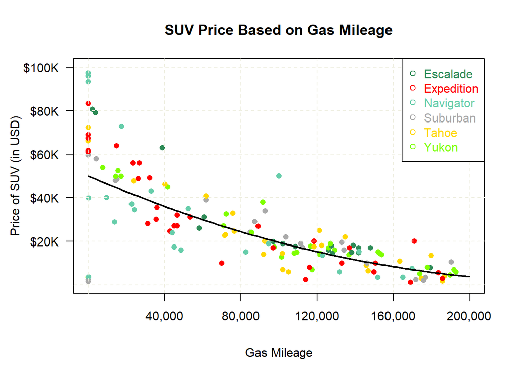

```r
SUVprices.lm<-lm(Price~Mileage,data=SUVprices)
SuburbanPrices<-subset(SUVprices,Model=="Suburban")
Suburban.lm<-lm(Price~Mileage,data=SuburbanPrices)
ExpeditionPrices<-subset(SUVprices,Model=="Expedition")
Expedition.lm<-lm(Price~Mileage,data=ExpeditionPrices)
TahoePrices<-subset(SUVprices,Model=="Tahoe")
Tahoe.lm<-lm(Price~Mileage,data=TahoePrices)
YukonPrices<-subset(SUVprices,Model=="Yukon")
Yukon.lm<-lm(Price~Mileage,data=YukonPrices)
EscaladePrices<-subset(SUVprices,Model=="Escalade")
Escalade.lm<-lm(Price~Mileage,data=EscaladePrices)
NavigatorPrices<-subset(SUVprices,Model=="Navigator")
Navigator.lm<-lm(Price~Mileage,data=NavigatorPrices)
SUVpriceslm.t<-lm(((Price)^(4/9))~Mileage,data=SUVprices)
palette(c("seagreen4","red","aquamarine3","darkgray","gold1","chartreuse"))
par(fg="black",col.lab="black",mai=c(1,1,.8,.4),mgp=c(3.5,1,0))
plot(Price~Mileage,data=SUVprices,pch=16,col=SUVprices$Model,main="SUV Price Based on Gas Mileage",ylab="Price of SUV (in USD)",xlab="Gas Mileage",yaxt="n",xaxt="n",ylim=c(0,100000),xlim=c(0,200000))
abline(v=c(0,40000,80000,120000,160000,200000),h=c(0,20000,40000,60000,80000,100000),col="ivory2",lty=2)
axis(1,at=c(40000,80000,120000,160000,200000),labels=c("40,000","80,000","120,000","160,000","200,000"),col.axis="black")
axis(2,at=c(20000,40000,60000,80000,100000),labels=c("$20K","$40K","$60K","$80K","$100K"),col.axis="black",las=2)
legend("topright",col=palette(),pch=21,legend=c("Escalade","Expedition","Navigator","Suburban","Tahoe","Yukon"),text.col=palette())
curve((SUVpriceslm.t$coef[1]+SUVpriceslm.t$coef[2]*x)^(9/4),add=TRUE,lwd=2)
```

Note to critiquer[^1]: **CLICK BUTTONS BELOW TO ACCESS SPECIFIED PARTS OF THE ANALYSIS.**

## Analysis

### Hypothesis

$$H_o: b_1 = 0\\
H_a: b_1 \neq 0$$

With an alpha level of $\alpha=0.05$.

### Unaltered Regression

#### Linear Regression Model

```r
pander(summary(SUVprices.lm))
```

|  | Estimate | Std. Error | t value | Pr(>\|t\|) |
| --- | --- | --- | --- | --- |
| **(Intercept)** | 52320 | 2105 | 24.86 | 3.985e-56 |
| **Mileage** | -0.2846 | 0.02002 | -14.21 | 6.079e-30 |

Fitting linear model: Price ~ Mileage

| Observations | Residual Std. Error | $R^2$ | Adjusted $R^2$ |
| --- | --- | --- | --- |
| 158 | 15273 | 0.5643 | 0.5615 |

$$\hat{Y}_i = 52320 - 0.2846 X_i$$

#### Diagnostic Plots

These are the diagnostic plots for the untransformed linear regression model:

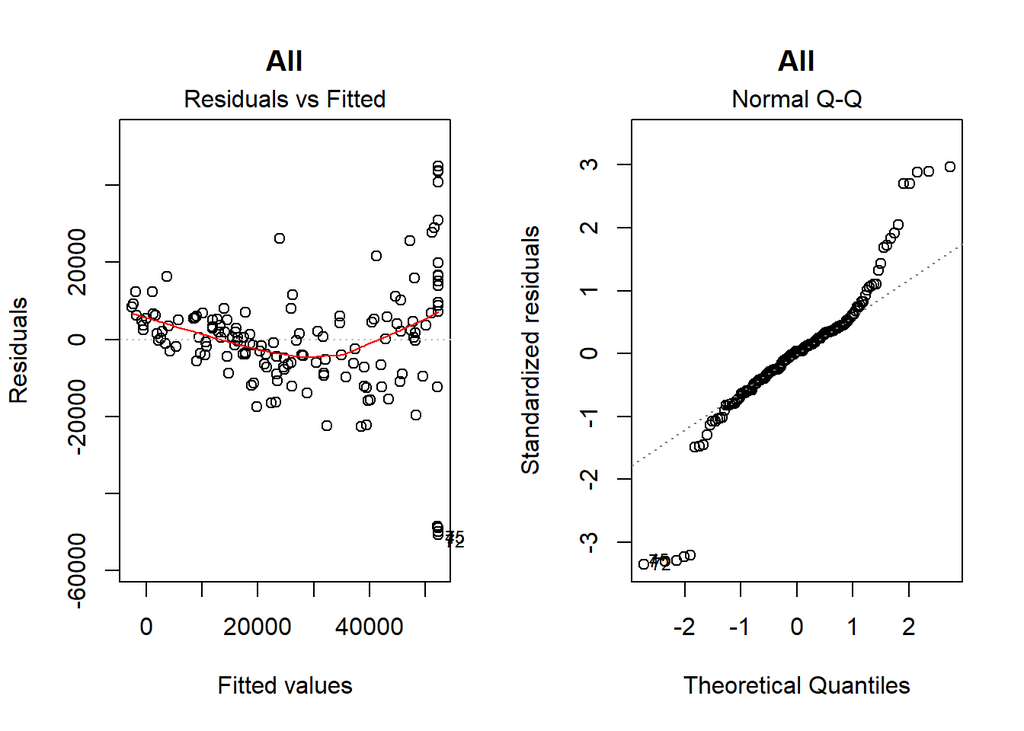

```r
##plot(Price~Mileage,data=EscaladePrices)
par(mfrow=c(1,2))
plot(SUVprices.lm,which=1:2,main="All")
```

From the residuals vs. fitted plot, we can see that the constant variance assumption is clearly violated. Also, the red line in the same plot is clearly not strait, so the linearity assumption is also violated. From the Q-Q plot we can see that the data is not normally distributed (it might even be two-tailed), so the assumption of normallity is also violated.

### Box-Cox

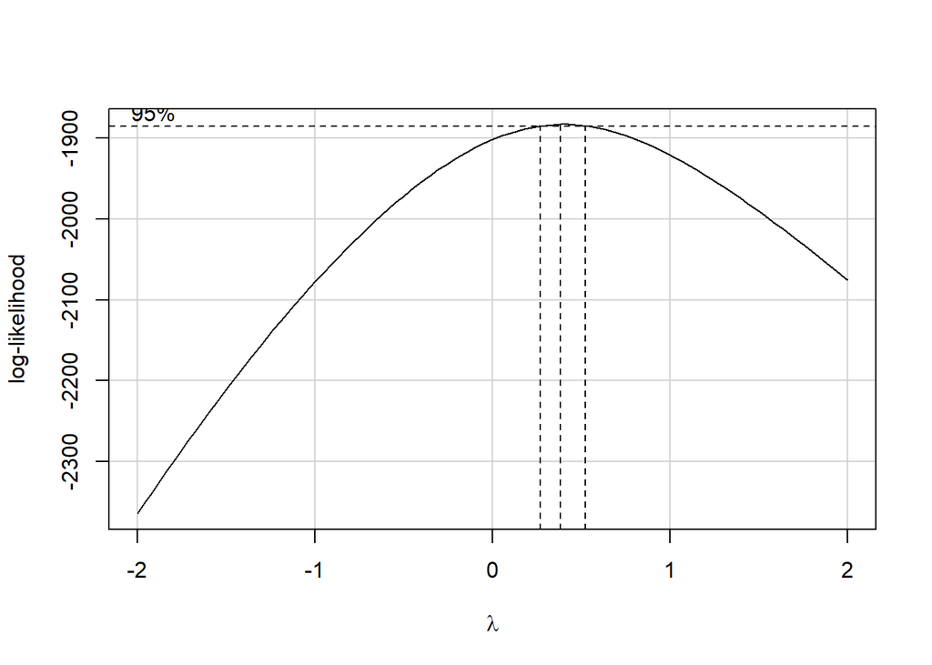

```r
boxCox(SUVprices.lm)
```

From the Box-Cox plot, we see that a lambda of $1/3$ is suggested as a transformation for $\hat{Y}_i$. However, after testing multiple different lambdas, the best transformation I could find involved using a lambda of $4/9$

### Transformed Regression

#### Linear Regression

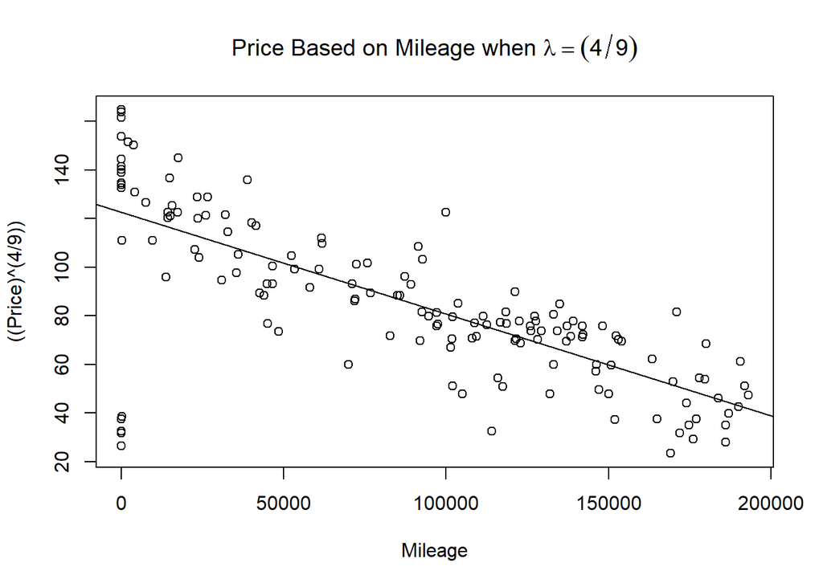

```r
plot(((Price)^(4/9))~Mileage,data=SUVprices,main=expression(paste("Price Based on Mileage when ",lambda==(4/9))))
abline(SUVpriceslm.t)
```

```r
pander(summary(SUVpriceslm.t))
```

|  | Estimate | Std. Error | t value | Pr(>\|t\|) |
| --- | --- | --- | --- | --- |
| **(Intercept)** | 122.7 | 3.103 | 39.56 | 3.175e-83 |
| **Mileage** | -0.0004199 | 2.951e-05 | -14.23 | 5.545e-30 |

Fitting linear model: ((Price)^(4/9)) ~ Mileage

| Observations | Residual Std. Error | $R^2$ | Adjusted $R^2$ |
| --- | --- | --- | --- |
| 158 | 22.51 | 0.5648 | 0.562 |

$$\hat{Y}_i = (122.7 - 0.0004199 X_i)^{9/4}$$

$p={5.545e^{-30}}$

#### Diagnostic Plots

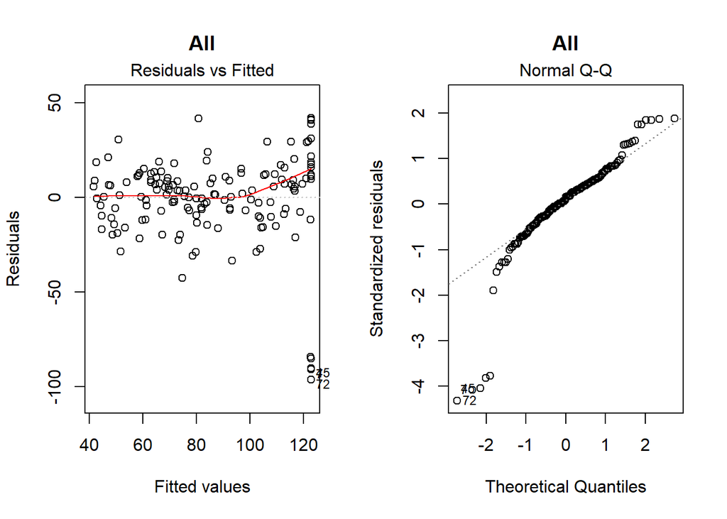

```r
par(mfrow=c(1,2))
plot(SUVpriceslm.t,which=1:2,main="All")
```

From the residuals vs. fitted plot, we can see that the variance of the residuals is much more constant than before. Also, the residuals are more linear. The only big problem is the Q-Q plot, which shows deviation from normality in the residuals to the left of the graph. However, this does not concern me that much.

### Conclusion

Since the p-value of the transformed linear regression is $p={5.545e^{-30}}$ (see the “Transformed Regression” tab) and the alpha value selected for this regression is $\alpha=0.05$ (see the “Hypothesis” tab), there is sufficient evidence to conclude that the slope of the regression model is not equal to 0.

[^1]: Data on SUVs was collected from [KSLauto.com](https://www.ksl.com/auto/).